# Luces nocturnas

Sesión 2 · jueves 1 de octubre de 2026

Diego A. Guerrero

Herramientas para el Nowcasting del Crecimiento del PIB · Bolivia

## La Tierra de Noche

La luz artificial nocturna es un **indicador indirecto de actividad**:

- consumo de energía, comercio y transporte
- actividad **informal**, que las encuestas captan mal
- crecimiento urbano y electrificación
- interrupciones: apagones, conflictos, desastres

Y llega **casi en tiempo real**.

~7 días

de rezago, frente a ~3 meses del PIB trimestral

# El dato

Parte 1

Qué mide el satélite y cómo se descarga

## El producto: NASA Black Marble

| **Producto** | VNP46A2: radiancia **diaria**, corregida por luna y atmósfera |
| --- | --- |
| **Resolución** | píxeles de ~500 m, cobertura global |
| **Unidad** | nW/cm²/sr |
| **Desde** | enero de **2012** |
| **Acceso** | NASA LAADS: cuenta gratuita + *token* (vence a los 60 días) |

Hay también un compuesto **mensual** (VNP46A3), más limpio pero con más rezago. En el taller usamos el diario y lo agregamos nosotros.

## ¿Qué es un nW/cm²/sr?

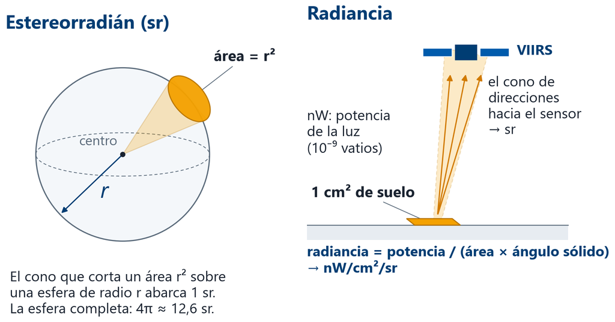

| en Bolivia | nW/cm²/sr |
| --- | --- |
| **mínimo** | **0** |
| fondo oscuro | ~0,2 |
| minas | ~3 |
| aeropuertos | ~13 |
| centros urbanos | 60–110 |
| refinería | ~150 |
| **máximo** | **sin tope** |

El producto no tiene techo: en Bolivia se ven píxeles de hasta ~40.000 (antorchas de gas, incendios).

**¿Cuánto mide un píxel?** En Bolivia, unos **460 m × 440 m ≈ 0,2 km²** (≈ 28 canchas de fútbol).

## Bolivia en piezas

La NASA reparte el planeta en **piezas** de 10° × 10°. Bolivia toca cinco; descargamos cuatro:

| pieza | % del territorio |
| --- | --- |
| h11v10 | 77,8 % |
| h11v11 | 14,8 % |
| h12v10 | 7,1 % |
| h11v09 | 0,3 % |
| h12v11 | 0,02 % |

**Presupuesto de disco.** Un archivo diario pesa ~25 MB → 4 piezas ≈ **100 MB por día**.

- un año ≈ 36 GB
- todo el archivo desde 2012 ≈ **500 GB**

## Septiembre contra septiembre

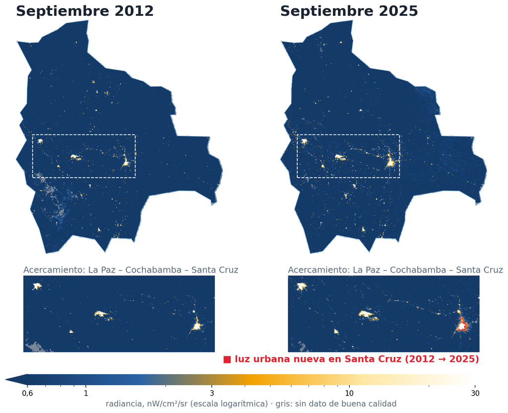

En 13 años:

- la superficie con **luz urbana** crece de unos **2.000 a 3.400 km²** (+69 %)
- se enciende la **ruta Cochabamba – Santa Cruz**
- **Santa Cruz** casi duplica su área iluminada: de **470 a 890 km²** (en rojo)

# La señal

Parte 2

De una imagen a una serie de tiempo, y qué dice del PIB

## De píxeles a una serie

### Por área

Promedio de todos los píxeles dentro del polígono de Bolivia (GADM).

### Por coordenadas

Radiancia en **90 lugares** con coordenadas: aeropuertos, hoteles, zonas industriales, minería, petróleo y gas, centros comerciales.

## El ruido diario y la señal trimestral

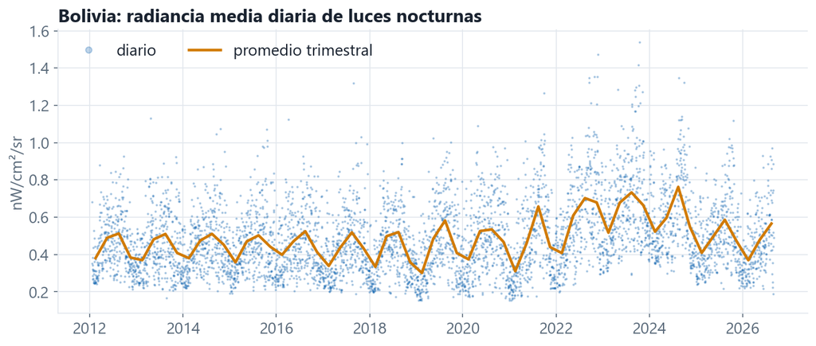

Picos a mitad de año, todos los años: estación seca (menos nubes) y temporada de quemas. **Estacionalidad que hay que quitar antes de modelar.**

## Comovimiento NTL-PIB

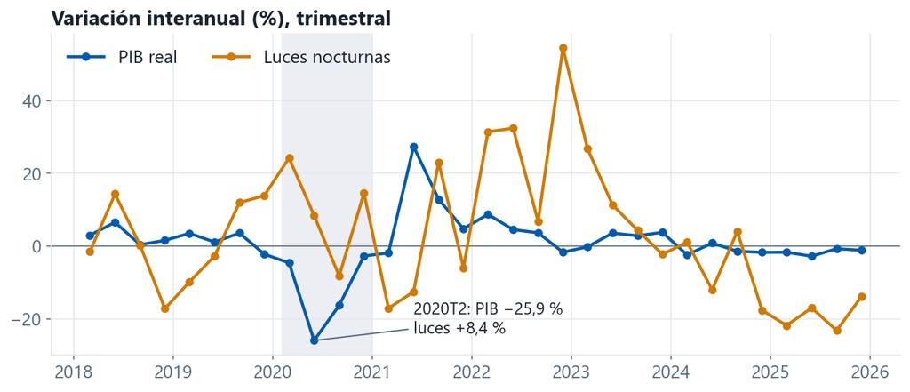

Correlación interanual: 0,04 (0,34 sin 2020–21)

## Coordenadas

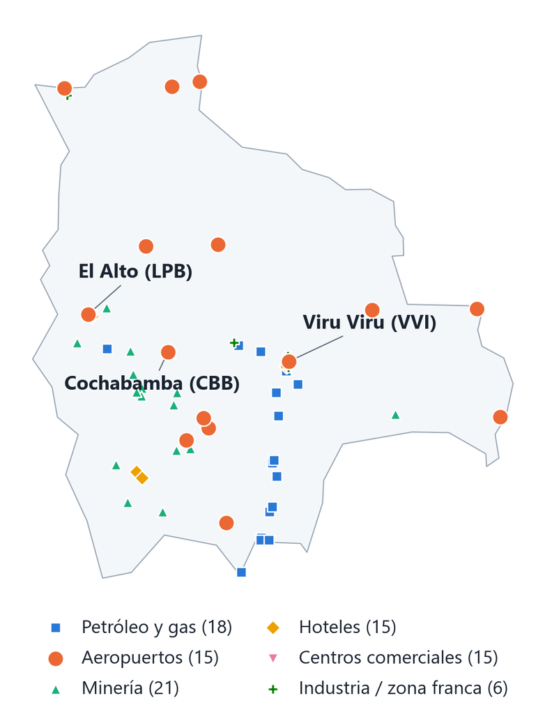

En vez de promediar todo el país, medimos la luz **alrededor de 90 puntos** con coordenadas, en 6 sectores.

- cada punto: promedio de **3 × 3 píxeles** (~1,4 km)
- ejemplos: los aeropuertos de **El Alto**, **Viru Viru** y **Cochabamba**

## Por sector: los aeropuertos sí ven el COVID

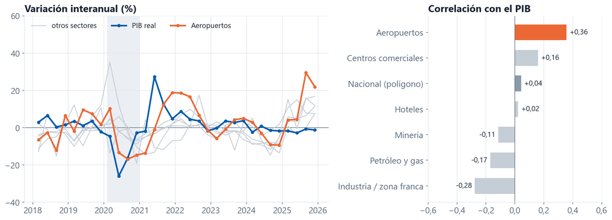

## Para finalizar

- La luz nocturna es **gratuita, diaria y rápida**, pero **ruidosa**
- Cuidado con **luna, nubes, resplandor del cielo e incendios**: no todo lo que brilla es actividad
- En Bolivia, la serie nacional **no reprodujo la caída de 2020**; por sitios, sólo los **aeropuertos** la acompañan

### Otros satélites útiles para Bolivia

| producto | qué capta | frecuencia · desde |
| --- | --- | --- |
| **Vegetación (NDVI/EVI)** · MODIS MOD13Q1 | vigor de los cultivos: soya, caña, pastos | cada 16 días · 2000 |
| **Cobertura del suelo** · MapBiomas Bolivia | superficie agrícola y su expansión | anual · 1985 |
| **Incendios y antorchas** · VIIRS (FIRMS, Nightfire) | quemas agrícolas, quema de gas | diario (en < 3 h) · 2012 |
| **Contaminación** · NO₂ Sentinel-5P, aerosoles MODIS | industria, transporte, PM2.5 | diario · NO₂ 2018, aerosoles 2000 |